Campus Data Plane · Sealed

# Decoupled AI Protocol for *AOL analytics*

Internal compliance briefing: what visuals and packages IT would approve vs refuse when AI assists Assurance of Learning analysis.

Control surfaces

- Control PlaneEmpty schemas only
- Data PlaneLocal sealed execution
- Break-glassLogged authorization

Nicholls State University  
IT Security · Office of the CIO

Chris Usey · Sam Cagle  
Synthetic PoC · 2026

In plain English

Big idea: AI can help write the recipe. The campus computer cooks the meal. Student records never leave campus.

01 · Purpose

## What leadership is asked to *recognize*

Not a request for a new cloud data processor. A pattern where AI drafts code from structure, campus hardware alone produces charts from synthetic stand-ins, and demographic×outcome work is blocked unless break-glass is logged.

### Distribution

- **Chris Usey** — IT Security Administrator
- **Sam Cagle** — CIO
- AOL / Senate awareness as needed

### Classification

- **DEVELOPMENT** — synthetic only
- Disney-character PII stand-ins
- Charts below are synthetic illustrations

### Decision focus

- Which **packages** may run locally
- Which **visuals** are in-bounds
- What stays forbidden without break-glass

In plain English

This is an FYI for IT leaders. We want a safer way to use AI for learning reports. We are not asking you to give student data to a new cloud company.

02 · What to approve

## Yes or no — quick guide

| Scenario | IT posture | Why |
| --- | --- | --- |
| Cloud AI receives empty schema + task text; returns plotting/analysis code | ACCEPTABLE | No education records / IPI leave campus |
| Local bar/heatmap/scatter from **key_academic** only (GPA, ETS, program) | ACCEPTABLE | AOL monitoring; no demographic linkage |
| Local matplotlib / seaborn / scipy / pandas / numpy on sealed host | ACCEPTABLE | Open-source; no vendor data ingest |
| Cloud AI receives row-level data, CSV uploads, or PII to “make the chart” | NOT ACCEPTABLE | FERPA / La. 17:3914 / CITI IPI exposure |
| Gender×GPA, race×ETS, or other demo×outcome visuals without break-glass log | NOT ACCEPTABLE | Sensitive linkage; default deny |
| openai / google.genai / requests used inside Data Plane against sealed tables | NOT ACCEPTABLE | Outbound path for education data |

Rule of thumb: if the cloud model could reconstruct a person or a protected education record from what you sent, it is refused. Structure and code are fine; observations are not.

In plain English

Approve when AI only sees blank column names and charts are made on campus. Refuse when anyone uploads student rows, names, or private details to an AI.

03 · Architecture

## Where packages and plots may run

Control Plane · Cloud

### May receive

- Empty schemas (column names / dtypes)
- “Draft a seaborn heatmap of gpa vs ets_score”
- Returned code snippets only

### Must not receive

- CSV / frame rows / chart image pixels of real data
- Disney/real names, emails, student IDs
- Joint demo×outcome schemas (pre–break-glass)

Data Plane · Campus

### Runs locally

- **pandas, numpy, scipy** — analysis
- **matplotlib, seaborn** — figures in this deck
- Human-in-the-Loop gate before execution
- Figures retained under university custody

PoC script: `scripts/decoupled_ai_protocol_poc.py`

In plain English

Two rooms. Cloud room: AI sees only an empty spreadsheet outline. Campus room: our tools make the charts. Student files stay in the campus room.

04 · Synthetic tables

## N = 100 · split before any plot

100

Synthetic cases

5

Programs

3

Partitions

0

Real students

identity_pii

### PII vault

Disney names + fake emails. Never plotted to cloud. Never in Control Plane prompts.

demographics

### Demographics

age_band, gender, race/ethnicity, residency. Unlinked IDs. No default join to outcomes.

key_academic

### AOL keys

GPA, ETS, program — source for all acceptable charts in this briefing.

In plain English

Demo uses 100 fake students (Disney names). Names, background facts, and grades sit in separate files so they are hard to recombine.

05 · OK charts

## Charts you *can* approve

Made on a campus computer with common open-source tools. An AI may help write the code from blank column names—but it never sees the real numbers.

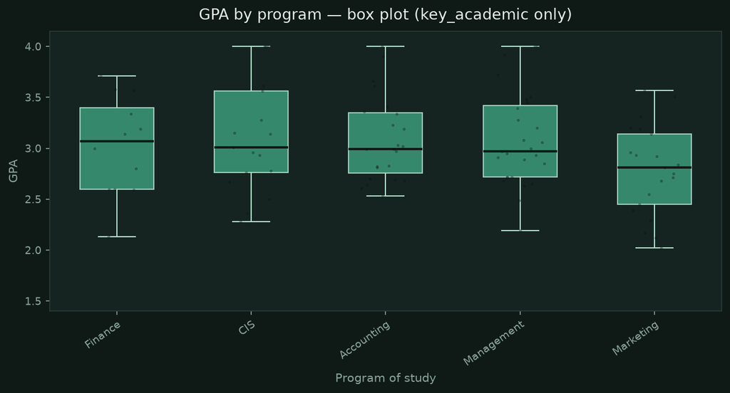

Box — GPA by program (major)  
Packages: pandas, seaborn, matplotlib

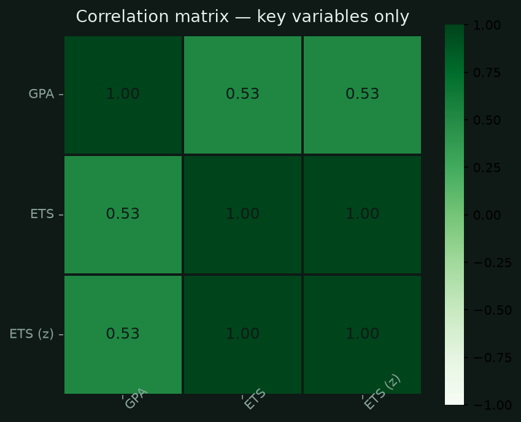

Heatmap — key correlations (left-angled labels)  
Packages: pandas, seaborn, matplotlib

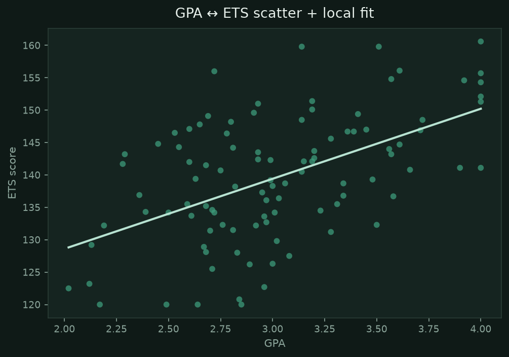

Scatter — GPA ↔ ETS + local fit  
Packages: numpy, scipy/polyfit, matplotlib

In plain English

These charts are fine. They use grades and test scores only—not gender or race. The AI never saw the numbers; a campus computer drew the pictures.

06 · Not acceptable by default

## Charts that mix background with grades

Do not approve these unless someone logs a special written OK first.

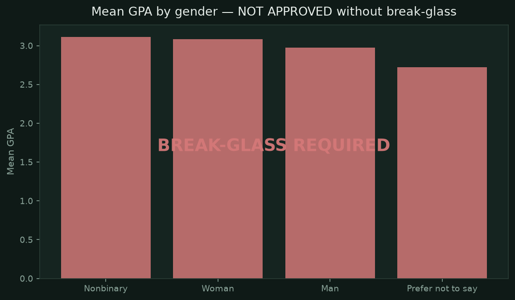

Bar — GPA by gender (linked)  
Status: NOT ACCEPTABLE without break-glass log

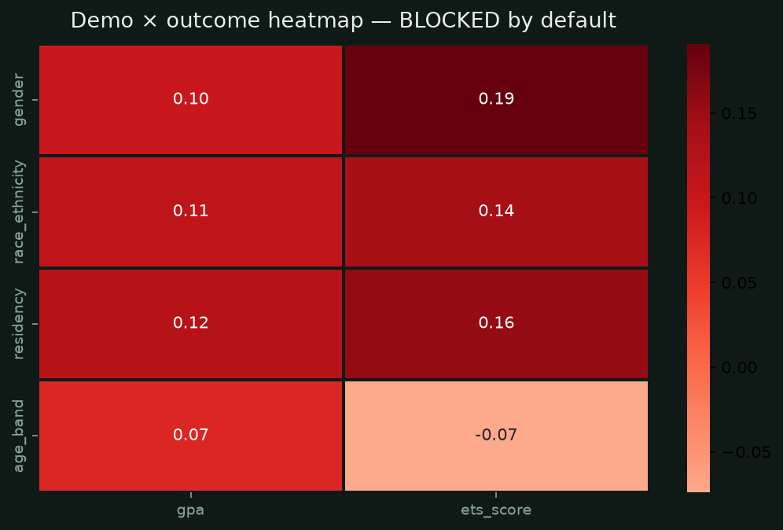

Heatmap — demographics × GPA/ETS  
Status: NOT ACCEPTABLE by default

In plain English

These charts are not fine by default. They mix personal background with grades. That needs a special written OK first. Even then, do not upload the data to an AI.

07 · Tools list

## Which software is OK

| Package / tool | Role | Plane | Posture |
| --- | --- | --- | --- |
| **pandas** | Tables, groupby for bar charts | Data Plane | APPROVE (local) |
| **numpy** | Arrays, fits, matrix ops | Data Plane | APPROVE (local) |
| **scipy** | Pearson / stats | Data Plane | APPROVE (local) |
| **matplotlib** | Bar, scatter export | Data Plane | APPROVE (local) |
| **seaborn** | Correlation / association heatmaps | Data Plane | APPROVE (local) |
| **Gemini / ChatGPT (schema-only)** | Draft plotting code from empty schema | Control Plane | APPROVE (no rows) |
| **google.genai / openai / anthropic SDKs** inside analysis script with data loaded | Would enable row egress | Data Plane | DO NOT APPROVE |
| **requests / httpx / curl uploads of CSV** | Transmit observations | Either | DO NOT APPROVE |

Approval question for IT: “Does this library open a network path that could carry education records?” If yes → refuse for Data Plane. Local viz stack above: no.

In plain English

Campus chart tools (pandas, matplotlib, seaborn) are fine. Cloud AI is fine only for writing code from blank column names. Tools that send data online during analysis are not fine.

08 · What the AI may see

## Blank labels only — never the numbers

[output not shown]

Simulated in PoC — this briefing does not call cloud APIs. Production Control Plane use stays schema-only by policy.

In plain English

For OK charts, AI may see empty field names like “gpa”—never the numbers. For background-plus-grades charts, do not share even the field list until a special written OK is logged.

09 · Special written OK

## When background + grades charts are allowed

### Required log fields

- timestamp_utc
- approver (name/role)
- reason
- analysis_requested
- tables_linked
- authorization_id

### Still forbidden after approval

- Uploading linked rows to Gemini/OpenAI
- Including PII vault columns in extracts
- Skipping Human-in-the-Loop attestation
- Treating synthpop tables as “anonymous enough” to send off-campus

Break-glass unlocks *local* linkage. It does not authorize cloud ingestion.

In plain English

A special written OK records who approved, why, and when. It unlocks joining files on campus. It does not allow sending student data to the cloud.

10 · What we need from IT

## Please file this as an FYI

Would approve

- Schema-only AI code assist
- Local pandas/numpy/scipy/matplotlib/seaborn
- Key-only AOL bars, heatmaps, scatters
- Synthpop-style local trend charts for discussion

Would not approve

- Cloud models seeing student/synthetic rows or PII
- Demo×outcome plots without break-glass log
- Network SDKs inside sealed analysis sessions
- CSV upload “for the AI to chart it”

Requested action

No vendor security review requested for schema-only Control Plane use. Please file as informational awareness for **Chris Usey** (IT Security) and **Sam Cagle** (CIO). Memo: `MEMO_TO_IT_LEADERSHIP` in the PoC script.

Nicholls State University · Decoupled AI Protocol v1.1.0-AOL-PoC

Arrow keys / Space · E to edit

In plain English

Please file this for Chris Usey and Sam Cagle. No new vendor review is needed for “blank outline only.” Do not approve uploads of student data to AI.

1 / 11